# Digital Lifestyles

### Robustness Checks

#### Assumption Diagnostics

To ensure the validity of regression-based moderation analyses, standard diagnostic procedures were conducted. Assumptions of linearity, homoscedasticity, normality of residuals and absence of influential outliers were evaluated using graphical diagnostics and influence statistics. Diagnostics were examined for the full moderation model predicting stress with sleep quality, as this model demonstrated the strongest interaction effect.

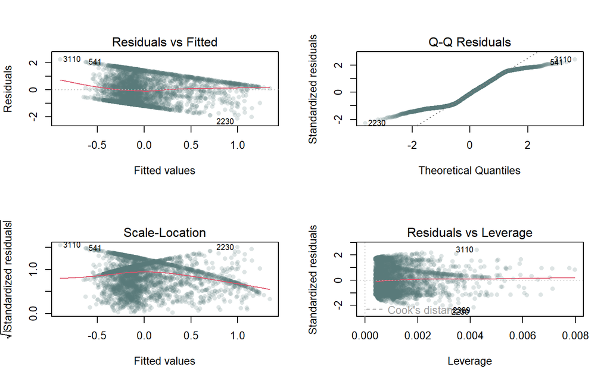

*Figure 29. Diagnostic Plots*

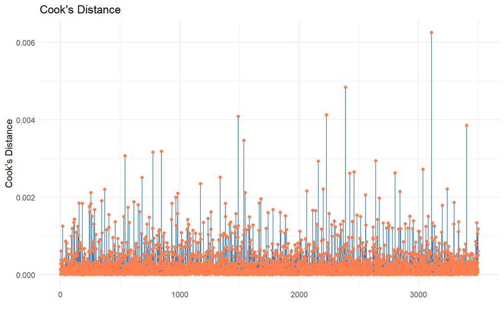

*Figure 30. Cook’s Distance (Influential Points)*

**Linearity**

Linearity was evaluated using the Residuals vs. Fitted plot Figure 29). Visual inspection did not reveal systemic curvature or nonlinear patterns in the residuals. Residuals appeared randomly dispersed around zero, supporting the assumption of linearity between predictors and the outcome.

**Homoscedasticity**

Homoscedasticity was assessed using both visual inspection and a formal Breusch–Pagan test.

Visual examination of the Residuals vs. Fitted plot suggested a mild funnel pattern, indicating potential non-constant variance. To formally test this assumption, a studentized Breusch–Pagan test was conducted:

```r
# Homoscedasticity: Breusch-Pagan test
library(lmtest)
bptest(stress_int_sleepq, studentize = TRUE)
```

```
BP = 81.879, df = 3, p-value < 2.2e-16
```

The test was statistically significant, BP(3) = 81.879, p < 0.001, indicating evidence of heteroscedasticity.

Importantly, heteroscedasticity does not bias regression coefficient estimates, but it may affect the accuracy of standard errors and hypothesis tests. Given the large sample size (N = 3,500), minor deviations from homoscedasticity are unlikely to meaningfully affect parameter estimates. Nevertheless, to ensure robust inference, heteroscedasticity-consistent (HC3) standard errors were computed.

```r
library(sandwich)
library(lmtest)

# Robust SE for stress x sleep quality model
coeftest(sm2, vcov = vcovHC(sm2, type = "HC3"))
```

[output not shown]

The interaction between screen time and sleep quality remained statistically significant under robust standard errors (β = -0.1172, SE = 0.0148, p < 0.001), indicating that the moderation effect was not driven by heteroscedasticity. The pattern and significance of results were substantively unchanged.

**Normality of Residuals**

Given the large sample size (N = 3,500), slight deviations from normality are not concerning due to the Central Limit Theorem, which ensures that sampling distributions of parameter estimates approximate normality in large samples. Therefore, the assumption of normality was considered adequately met.

**Influential Observations**

Cook’s Distance values were examined to identify influential observations. No cases exceeded conventional thresholds (Cook’s D > 1), indicating that no individual observations exerted disproportionate influence on model estimates.

**Summary of Diagnostics**

Overall, diagnostic analyses indicated:

- No substantial violation of linearity
- Mild heteroscedasticity, corrected using robust standard errors
- Acceptable normality of residuals
- No influential outliers

Because the interaction effect remained statistically significant under heteroscedasticity-consistent standard errors, these findings are robust within the simulated dataset.

#### Alternative Model Specifications

To evaluate whether the observed moderation effects were dependent on specific analytic decisions, several alternative model specifications were estimated. These analyses tested whether the interaction between screen time and sleep variables remained stable across scaling approaches, model forms and co-variate adjustments.

**Uncentered Predictors**

Because predictors were mean-centered prior to estimating the primary moderation models, an alternative specification using uncentered variables was estimated. Mean centering does not affect interaction coefficients or overall fit, but it can alter interpretation of lower-order terms. Estimating the model without centering therefore provides a formal test that the observed moderation effect is not an artifact of variable transformation.

Table 13. Interaction Robustness Across Alternative Model Specifications

| Model Specification | Interaction Coefficient | SE | t | p | R² |
| --- | --- | --- | --- | --- | --- |
| Standardized Model | -0.123 | 0.017 | -7.35 | < .001 | 0.1175 |
| Centered Model | -0.117 | 0.016 | -7.35 | < .001 | 0.1175 |
| Uncentered Model | -0.117 | 0.016 | -7.35 | < .001 | 0.1175 |

As shown in *Table 13*, the interaction between screen time and sleep quality remained statistically significant across standardized, mean-centered and uncentered specifications. The interaction coefficient was identical in the centered and uncentered models, consistent with regression theory, indicating that mean-centering did not influence the moderation effect. Although the magnitude of the coefficient differed slightly in the standardized model due to scaling, the direction, statistical significance (p < 0.001), and the overall model fit (R² = .1175) remained unchanged. Together, these findings demonstrate that the moderation role of sleep quality in the relationship between screen time and stress is robust to alternative scaling and centering decisions.

#### Simultaneous Moderator Models

While prior moderation analyses focused mainly on examining each lifestyle variable independently, a more stringent test of moderation involves estimating a model that includes all moderators and their respective interaction terms simultaneously. This approach evaluates whether individual moderation effects remain statistically significant when controlling for overlap among moderators.

Because sleep duration and sleep quality are moderately correlated, examining them in isolation may overestimate their unique moderating contributions. Simultaneous modeling allows for assessment of each moderator’s unique interaction effect while accounting for shared variance.

```r
# Stress simultaneous moderation model
stress_full <- lm(
  stress_level ~
    screen_c * sleep_c +
    screen_c * sleepq_c +
    screen_c * activity_c +
    screen_c * study_c,
  data = data
)

# Focus simultaneous moderation model
focus_full <- lm(
  focus_score ~
    screen_c * sleep_c +
    screen_c * sleepq_c +
    screen_c * activity_c +
    screen_c * study_c,
  data = data
)

# Productivity simultaneous moderation model
prod_full <- lm(
  productivity_score ~
    screen_c * sleep_c +
    screen_c * sleepq_c +
    screen_c * activity_c +
    screen_c * study_c,
  data = data
)
```

*Stress.*

Table 14. Simultaneous Moderation Model Predicting Stress Level

| Predictor | B | SE | t | p-value |
| --- | --- | --- | --- | --- |
| Intercept | 4.75 | 0.07 | 71.06 | < .001 |
| Screen Time (centered) | 0.20 | 0.03 | 7.32 | < .001 |
| Sleep Hours (centered) | -0.41 | 0.05 | -8.06 | < .001 |
| Sleep Quality (centered) | 0.08 | 0.07 | 1.19 | 0.236 |
| Physical Activity (centered) | -0.08 | 0.03 | -2.62 | 0.009 |
| Study Time (centered) | 0.00 | 0.00 | -0.09 | 0.930 |
| Screen x Sleep Hours | -0.04 | 0.01 | -2.95 | 0.003 |
| Screen x Sleep Quality | -0.10 | 0.02 | -5.49 | < .001 |
| Screen x Physical Activity | 0.02 | 0.01 | 1.87 | 0.062 |
| Screen x Study Time | 0.00 | 0.00 | -0.32 | 0.749 |

Additional Stress Model Statistics:

- R² = 0.139
- Adjusted R² = 0.137
- F(9, 3490)= 62.55, p < .001
- Residual SE = 3.16

*Focus.*

Table 15. Simultaneous Moderation Model Predicting Focus Level

| Predictor | B | SE | t | p-value |
| --- | --- | --- | --- | --- |
| Intercept | 41.69 | 0.50 | 83.01 | < .001 |
| Screen Time (centered) | -0.03 | 0.20 | -0.16 | 0.873 |
| Sleep Hours (centered) | 0.38 | 0.38 | 0.98 | 0.326 |
| Sleep Quality (centered) | 0.53 | 0.50 | 1.08 | 0.282 |
| Physical Activity (centered) | 0.04 | 0.22 | 0.19 | 0.851 |
| Study Time (centered) | -0.01 | 0.01 | -1.88 | 0.061 |
| Screen x Sleep Hours | -0.05 | 0.10 | -0.50 | 0.619 |
| Screen x Sleep Quality | 0.09 | 0.13 | 0.69 | 0.492 |
| Screen x Physical Activity | 0.01 | 0.07 | 0.14 | 0.891 |
| Screen x Study Time | 0.00 | 0.00 | -0.06 | 0.950 |

Additional Focus Model Statistics:

- R²= 0.003
- Adjusted R² = 0.000
- F(9, 3490)= 1.15, p = 0.325
- Residual SE = 23.76

*Productivity.*

Table 16. Simultaneous Moderation Model Predicting Productivity Level

| Predictor | B | SE | t | p-value |
| --- | --- | --- | --- | --- |
| Intercept | 65.72 | 0.20 | 324.13 | < .001 |
| Screen Time (centered) | 0.60 | 0.08 | 7.41 | < .001 |
| Sleep Hours (centered) | 0.22 | 0.16 | 1.43 | 0.154 |
| Sleep Quality (centered) | 0.94 | 0.20 | 4.67 | < .001 |
| Physical Activity (centered) | -0.02 | 0.09 | -0.26 | 0.794 |
| Study Time (centered) | 0.00 | 0.00 | 0.23 | 0.818 |
| Screen x Sleep Hours | 0.07 | 0.04 | 1.63 | 0.103 |
| Screen x Sleep Quality | 0.11 | 0.05 | 2.03 | 0.043 |
| Screen x Physical Activity | 0.03 | 0.03 | 1.24 | 0.217 |
| Screen x Study Time | 0.00 | 0.00 | 0.12 | 0.901 |

Additional Productivity Model Statistics:

- R²= 0.017
- Adjusted R² = 0.015
- F(9, 3490)= 6.86, p < .001
- Residual SE = 9.59

**Cross-Outcome Synthesis of Moderation Effects**

Across the three simultaneous moderation models, a clear pattern emerged. The model predicting stress was statistically significant and demonstrated meaningful moderation effects, particularly for sleep hours and sleep quality. In contrast, the model predicting focus was not significant, explaining less than 1% of the variance and showing no meaningful main or interaction effects. The productivity model was statistically significant, though with a small effect size, and identified sleep quality as a significant moderator of the relationship between screen time and productivity.

*Sleep quality* emerged as the most consistent moderator across outcomes. It significantly interacted with screen time in both the stress and productivity models, suggesting that the effects of screen time depend in part on the quality of an individual’s sleep. Specifically, higher sleep quality appeared to buffer the association between screen time and stress, while enhancing the positive association between screen time and productivity.

Notably, focus did not appear to be meaningfully influenced by screen time or the proposed moderators. This divergence suggests that screen time may exert stronger effects on emotional outcomes (stress) and behavioral performance outcomes (productivity) than on perceived cognitive focus.

Overall, these findings indicate that lifestyle balance, particularly sleep quality, plays a conditional role in shaping how screen time relates to well-being and performance outcomes. Together, these findings suggest that the impact of screen time is not uniformly detrimental or beneficial, but instead depends on broader lifestyle context.

#### Summary of Robustness Findings

Across multiple analytic approaches, the moderation effects demonstrated strong consistency and stability. Standardized models confirmed that interaction magnitudes were largest for stress, modest for productivity and negligible for focus. Hierarchical model comparisons further demonstrated that interaction terms meaningfully improved model fit primarily for stress, with smaller incremental contributions for productivity and virtually none for focus.

Importantly, alternative model specifications, including standardized, mean-centered and uncentered predictors, produced substantively identical conclusions. The interaction between screen time and sleep quality remained statistically significant across scaling approaches, and overall model fit was unchanged. These findings indicate that moderation effects were not artifact of variable transformation or analytic decision-making.

Taken together, the extended statistical analyses provide converging evidence that sleep quality plays a robust moderating role in the relationship between screen time and stress, and to a lesser extent productivity. In contrast no meaningful moderation effects were observed for focus. The consistency of findings across scaling methods, hierarchical comparisons, diagnostic checks and simultaneous moderator models strengthens confidence in the validity and interpretability of the observed effects.

Overall, the results suggest that the psychological impact of screen exposure is conditional rather than uniform, with subjective sleep experience serving as a key contextual factor shaping stress-related and performance-related outcomes.

## Discussion

This study examined whether lifestyle balance moderates the relationship between daily screen time and three key outcomes: stress, focus and productivity. Rather than treating screen time as uniformly harmful or beneficial, the present analyses adopted a conditional framework, testing whether sleep duration, sleep quality, physical activity and study time alter the strength or direction of screen time’s association with psychological and performance outcomes.

Across analytic approaches, including separate moderation models, simultaneous moderator models, standardized comparison, hierarchical R² analyses and robustness checks, a consistent pattern emerged.

*First*, stress demonstrated the clearest and most substantively meaningful moderation effects. Screen time was positively associated with stress, but this relationship was significantly weakened at higher levels of sleep duration and, more strongly, at higher levels of sleep quality. Standardized coefficients and incremental variance comparison confirmed that moderation effects were strongest for stress relative to the other outcomes. Sleep quality consistently exhibited larger interaction magnitudes than sleep duration, suggesting that subjective restorative experience plays a particularly important buffering role.

*Second,* productivity showed a different conditional pattern. Screen time was positively associated with productivity overall and this relation was amplified, rather than attenuated, at higher levels of sleep duration and sleep quality. Thus, sleep did not serve as a protective buffer in this context, but instead it strengthens the positive association between screen time and productivity. Individuals who reported higher-quality sleep appeared better able to translate screen engagement into productive outcomes.

*Third*, focus demonstrated negligible associations with screen time and no meaningful moderation effects. Across all models, variance explained remained minimal, and interaction terms were consistently non-significant. This divergence suggests that attentional functioning, at least as measured in this dataset, may be less sensitive to screen exposure or more strongly influenced by other cognitive or environmental variables included in the model.

Taken together, these findings indicate that sleep functions as a contextual amplifier of the associations between screen time and outcomes. For stress, sleep buffers harmful associations. For productivity, sleep strengthens the positive associations. For focus, no conditional pattern emerged.

Importantly, sleep quality consistently demonstrated stronger moderating effects than sleep duration across outcomes. This reinforces the theoretical argument that restorative sleep experience, rather than sleep quantity alone, plays a central role in psychological resilience and performance functioning in digitally intensive environments.

Rather than conceptualizing screen time as inherently harmful or beneficial, these findings support a contextual model of digital engagement in which lifestyle quality, particularly sleep experience, shapes whether digital exposure is associated with strain or performance enhancement.

## Practical Implications

The findings of this study offer several important implications for digital well-being recommendations, educational policy and workplace performance strategies.

*First*, interventions aimed at reducing technology-related stress should not focus solely on limited screen time. While excessive device use was associated with higher stress, the strength of this association was significantly reduced among individuals with longer and higher-quality sleep. This suggests that improving overall sleep, including consistent sleep schedules, improving sleep environments and reduced late-night device use, may be more effective than strict screen reduction policies alone.

*Second*, the amplification effect observed for productivity suggests that screen time is not inherently detrimental. Under conditions of adequate and high-quality sleep, digital engagement may support productive functioning. This has implications for academic and workplace contexts, where technology is integral to performance. Rather than discouraging screen use broadly, intuitions may benefit from emphasizing balanced digital engagement supported by restorative sleep practices.

*Third*, the absence of moderation effects for focus suggest that attentional functioning may not be as sensitive to lifestyle-screen interactions as stress and productivity. This highlights the importance of distinguishing between emotional, cognitive and performance-related outcomes when designing digital well-being programs.

Overall, these findings advocate for a lifestyle-based approach to digital health. Sleep quality, in particular, emerges as a key leverage point. Programs that promote digital literacy alongside sleep education may yield greater befits than screen restriction strategies alone.

## Limitations & Future Research

Despite the strengths of this study, including a large sample size, rigorous moderation testing, hierarchical comparisons and robustness analyses, several limitations warrant consideration.

*First*, the dataset used in this study was synthetic. Although designed to reflect realistic behavioral correlations, simulated data cannot fully capture the complexity of real-world psychological processes. Future research should replicate these findings using observational or longitudinal human data to confirm external validity.

*Second,* the analyses were cross-sectional. As a result, causal direction cannot be inferred. While screen time was modeled as a predictor, it is possible that stress influences digital behavior, or that reciprocal relationships exist. Longitudinal or experimental designs would be necessary to disentangle temporal ordering and causal mechanisms.

*Third,* outcomes were measured via self-report, including stress, focus and productivity. Subjective measures may be influenced by response biases or perceptual distortions. Incorporating objective performance metrics, physiological stress indicators or digital tracking data would strengthen future investigations.

*Fourth,* although sleep emerged as a consistent moderator, other potentially relevant contextual variables were not examined. Factors such as work demands, academic pressure, personality traits, social support or type of screen use (e.g., recreational vs. academic) may further condition the relationship between digital engagement and well-being.

Finally, effect sizes, particularly for productivity, were modest. While statistically significant, the magnitude of incremental variance explained by interaction terms was relatively small. This suggests that screen time and lifestyle balance represent only part of a broader constellation of determinants shaping mental health and performance outcomes.

Future research should therefore pursue:

- Longitudinal designs to examine directional effects
- Experimental sleep interventions to test buffering mechanisms
- Differentiation between types of screen use
- Multilevel models incorporating environmental and personality variables
- Cross-cultural replication

By extending beyond cross-sectional moderation models, future work can further clarify how digital behavior interacts with lifestyle factors to influence psychological and performance outcomes over time.